# Creating an Index Fund using Integer Programming

May 20, 2017

# Discussion

There is a ongoing debate between active and passive management that will probably never end. On average, active fund managers tend to underperfom by the amount of fees charged. This implies that a buy and hold strategy with index funds is a good choice. Index funds have begun to dominate the stock market and it would be useful to understand how one may construct one in practice. We will use an integer program to select a subset of stocks to represent the whole. Consider the S&P 500. One can go out and buy in proportion every stock in the S&P. This index fund would be highly accurate but would lose money because of turnover and transaction costs. Instead, we should select a subset of stocks which most correlates with the S&P 500 in order to replicate the S&P 500 without purchasing every security. In this example, we will create an index fund to track the oil and gas industry.

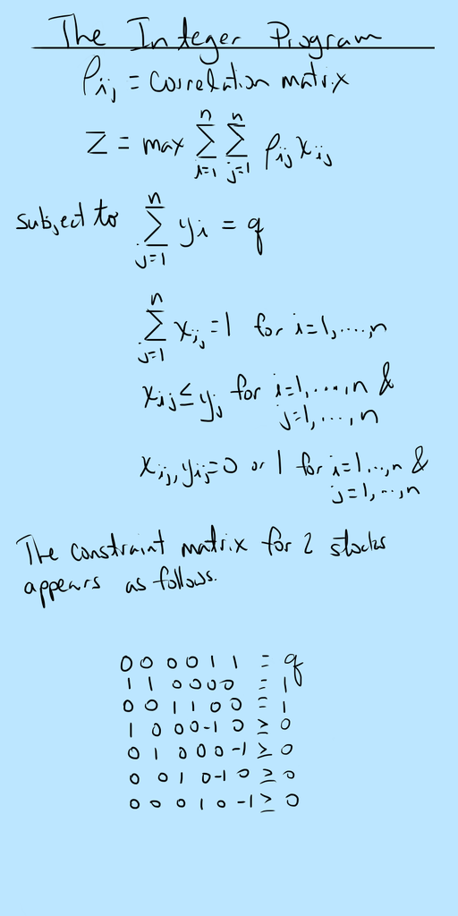

```r
library(data.table) # To read data online
library(quantmod)   # To get stock returns
library(tidyquant)  # To get market capitalization
library(ggplot2)    # To plot
library(ggthemes)   # Makes ggplot2 prettier
library(lpSolve)    # To run the integer program
library(corrplot)   # To create correlation matrix
```

# Obtaining/Cleaning The Data

YOU CAN SKIP THIS PART AND MOVE STRAIGHT TO “CREATING THE FUND” IF YOU DESIRE. I HAVE THE DATA CLEANED AND READY FOR YOU.

First, we’ll download tables from online which contains metadata about stocks on the NYSE and Nasdaq. It gives descriptions about the type of industry the stock is in, the IPO date, etc.

```r
nasdaq = fread("http://www.nasdaq.com/screening/companies-by-industry.aspx?exchange=NASDAQ&render=download")
nyse = fread("http://www.nasdaq.com/screening/companies-by-industry.aspx?exchange=NYSE&render=download")
```

Next we’ll get only the stocks which are labeled as Oil and Gas Production.

```r
nasOng = nasdaq[nasdaq$Industry=="Oil & Gas Production"]
nyseOng = nyse[nyse$Industry=="Oil & Gas Production"]
```

We’ll combine the tickers here.

```r
tickers = append(nyseOng$Symbol, nasOng$Symbol)
```

And remove any spaces.

```r
tickers = gsub(" ","", tickers)
```

Now, we’ll get the monthly returns for all of the tickers.

```r
stockList = list()
for(stock in tickers) {
     stockList[[stock]] = try(monthlyReturn(getSymbols(stock, src = "google", auto.assign = FALSE), type = "log"))
     print(stock)
}
```

Next, we’ll select only those stocks which have more than 60 months of returns. Some stocks are newer and don’t have much historical data. `goodStocks` is a list that holds the returns and `goodTickers` holds the tickers of the companies with greater than 60 months returns.

```r
goodStocks = list()
goodTickers = vector()
for(i in 1:length(stockList)) {
     if (length(nrow(stockList[[tickers[i]]])) != 0) {
          if(nrow(stockList[[tickers[i]]]) >= 60) {
               goodStocks[[tickers[i]]] = stockList[[tickers[i]]]["2015-01-01::"]
               goodTickers = append(goodTickers, tickers[i])
          }
     }
}
```

The dates are rownames currently, and we need rownames to be able to combine each of the returns to the appropriate timeperiod.

```r
dates = as.Date(rownames(as.data.frame(goodStocks[[goodTickers[1]]])))
returns = as.data.frame(goodStocks[[1]])[,1]
```

Now, we’ll combine all the returns into a dataframe.

```r
df = data.frame(dates = dates, returns = returns)
colnames(df) = c("dates", goodTickers[1])

for(i in 2:length(goodTickers)) {
stockReturns = as.data.frame(goodStocks[[goodTickers[i]]])
stockReturns$dates = as.Date(rownames(stockReturns))
colnames(stockReturns) = c(goodTickers[i], "dates")
df = merge.data.frame(x = df, y = stockReturns)
}
```

Now, we need to get the market capitalization for each stock in order to determine appropriate weights.

```r
stats = tq_get(goodTickers, "key.stats")
```

This is the data we will need for the integer program. `goodStocks` contains the tickers, `marketCap` contains the market capitalization for each stock and `dfNoDate` is a data.frame of stock returns without the dates. This will allow up to create a correlation matrix.

```r
# These are the three variables we will use for the optimization.
goodStocks = stats$symbol
marketCap = stats$Market.Capitalization
dfNoDate = df[goodStocks]
```

# Creating the Fund

YOU CAN START HERE AFTER LOADING THE PACKAGES ABOVE

The variables above can be downloaded directly from my website. Let’s take a look.

```r
marketCap = read.csv("http://fdrennan.net/pages/pages2/datasets/marketCap.csv")
marketCap = as.vector(marketCap[,1])
dfNoDate = read.csv("http://fdrennan.net/pages/pages2/datasets/dfNoDate.csv")
goodStocks = colnames(dfNoDate)
```

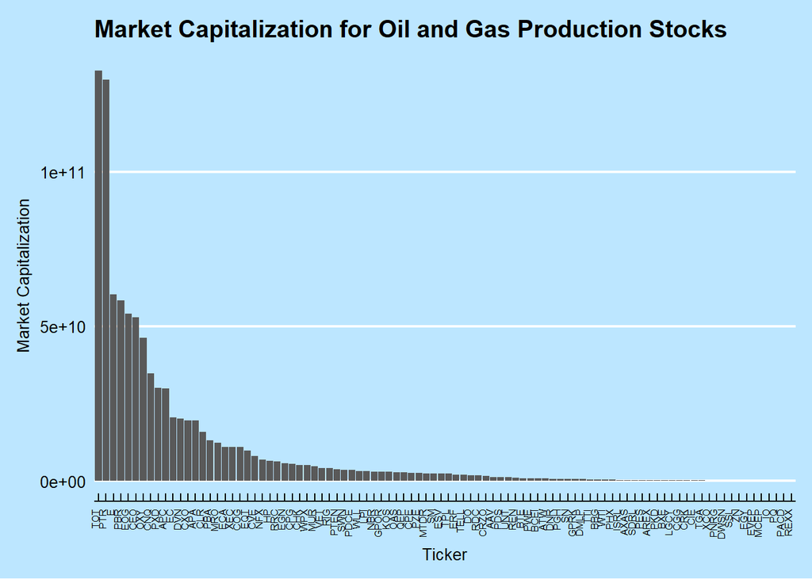

```r
ggdf = data.frame(marketCap = marketCap, goodStocks = goodStocks)

ggplot(ggdf, aes(x = reorder(goodStocks, -marketCap), y = marketCap)) +
     geom_bar(stat = "identity") +
     theme_economist() +
     theme(axis.text.x = element_text(angle = 90, hjust = 1, size = rel(.6))) +
     xlab("Ticker") +
     ylab("Market Capitalization") +
     ggtitle("Market Capitalization for Oil and Gas Production Stocks") +
     theme(panel.background = element_rect(fill = "#BCE6FF"), plot.background = element_rect(fill = "#BCE6FF"))
```

Next, we’ll create a correlation matrix of our stocks and visualize it. We can see that there is a lot of correlation between each of these stocks which makes sense given that they are all equities and in the same industry. A word of caution when running this type of optimization. There is a ton of error in the correlation matrix. If one is to create this type of index fund, it may be better to create stratified samples before running the optimization as well as condition the returns to be forward looking with James-Stein estimators.

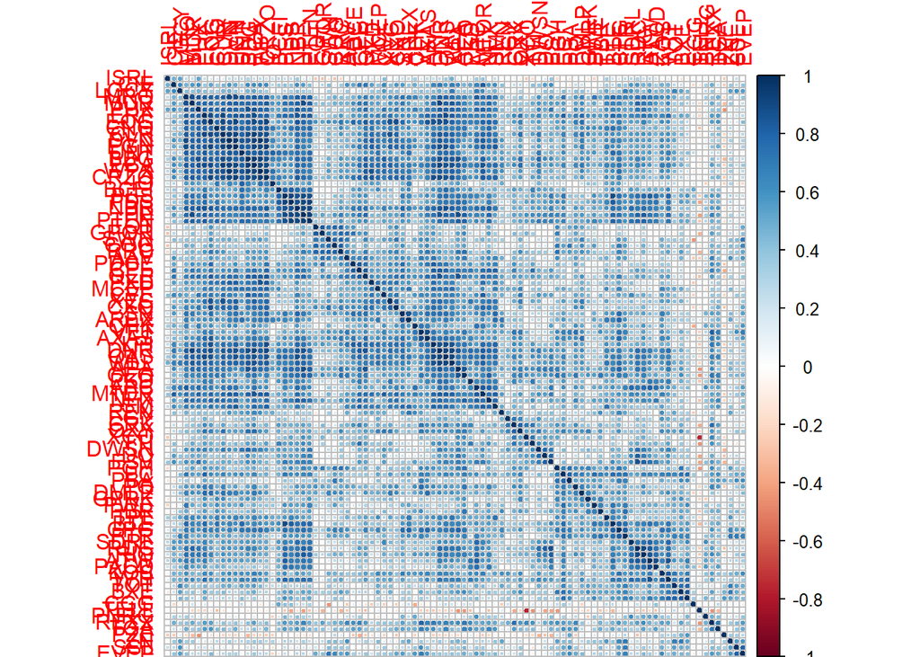

```r
rho = cor(dfNoDate)
corrplot(rho, order = "hclust")
```

q is the number of stocks we would like in our index fund.

```r
q = 25
```

```r
colLength <- ncol(rho)
```

For the first constraint, we will pick q stocks.

```r
#for 1st constraint (pick 25)
firstRow <- c(rep(0, colLength^2), rep(1,colLength))
```

For the second constraint every stock must be represented exactly one time.

```r
secondRows <- matrix(0, nrow = colLength, ncol = (colLength^2+colLength))
beg <- 1
end <- colLength
for(row in 1:colLength) {
secondRows[row, beg:end] <- 1
beg <- beg + colLength
end <- end + colLength
}
```

For 3rd constraint stock $x_ij$ can only be represented if $y_j$ is selected.

```r
diagMat = diag(1,
          colLength^2,
          colLength^2)

negDiagMat = diag(-1,
             colLength,
             colLength)

negDiagMat = matrix(negDiagMat,
               colLength^2,
               colLength,byrow=T)
```

Combine constraint matrices together.

```r
lowerRight = cbind(diagMat,
              negDiagMat)
```

Create objective function.

```r
obj <-  c(rho,
     rep(0,colLength))
```

Create right hand side of constraint matrix.

```r
b <-  c(q,
   rep(1,colLength),
   rep(0,colLength^2))
```

Combine all constraint matrices together into one.

```r
A = rbind(firstRow,secondRows,lowerRight)
```

Specify direction of constraints.

```r
dir = c(rep("=",(colLength+1)), rep("<=",colLength^2))
```

# The Solution

Solve the lp. `all.bin` indicates that the solution should be integers.

```r
s = lp("max", obj, A, dir, b, all.bin = TRUE)
```

Select the portion of the solution which indicates which stocks are selected.

```r
back=(length(s$solution)+1)-length(goodStocks)
end=length(s$solution)

stockBinary=s$solution[back:end]
```

Find the ticker/market caps for stocks that the binary solution indicates.

```r
solStocks=goodStocks[stockBinary==TRUE]
solCap = marketCap[stockBinary==TRUE]
```

Determine the proportion of each stock to invest in using market cap as indicator.

```r
percentages = solCap/sum(solCap)
names(percentages) = solStocks
percentages
```

```
##          ATW          CGG          CRK          DNR           EC
## 0.0023227933 0.0004235620 0.0004149077 0.0022595276 0.0677420600
##            E          EOG         GPRK           HP          KOS
## 0.1998772088 0.1795512750 0.0016943473 0.0216191009 0.0097484903
##         MTDR          PZE          PTR          PES          RRC
## 0.0080905838 0.0081900582 0.4305583206 0.0007411174 0.0206243570
##          RDC          SSL          VET          WPX         AREX
## 0.0057695147 0.0002918910 0.0138600984 0.0166785395 0.0006863733
##         ISRL         LGCY         PNRG         TELL          TGA
## 0.0010018066 0.0005105026 0.0003300560 0.0066316260 0.0003818822
```

Find the stocks which have a proportion worth considering investment.

```r
round(percentages[percentages > 0.01], 2)
```

```
##   EC    E  EOG   HP  PTR  RRC  VET  WPX
## 0.07 0.20 0.18 0.02 0.43 0.02 0.01 0.02
```